# Modelling atmospheric CO2 with time-series

Marius Dioli, Amir Ahmed and Andreas Ferstad

September 2019

# Abstract

This article presents the basics of time series analysis, and applies it to model monthly average atmospheric CO2 levels observed at Mauna Loa Observatory, Hawaii, U.S.

# Introduction

# Theory

We note that large parts of the theory presented here, is based on Brockwell and Davis.

A timeseries can be considered as a stochastic process, a set of random variables indexed in accordance to their occurrence relative to the other measurements. We will organize the finite timeseries we will deal with into vectors: $\mathbf{X}= ( X_1, X_2, \dots,X_n)^T$. A realization of a timeseries is an observation of the the real values of the time series, and will be denoted as $\mathbf{x} = (x_1, x_2, \dots, x_n)^T$

The covariance function of two elements of $\mathbf{X}$ is defined as:
$$\gamma_X(r,s)=Cov(X_r, X_s)=E((X_r-E(X_r))(X_s-E(X_s))$$
In general the covariance function tells us how observations correlate to each other.

A time series is weakly stationary if:

- $E(X_t)$ is independent of $t$
- $\gamma_X(t+h, t)$ is independent of t at each h value.

In a weakly stationary timesries the correlation between two observations would only be depended the relative time between the observation of the repsective observations.

The auto correlation function at a selected lag $h$ is:
$$\rho_X(h)=\dfrac{\gamma_X(h)}{\gamma_X(0)}$$
Where lagging a time-series is shifting it forward by a selected amount of indexes.

The estimator of the autocovariance of a realized time-series, referred to as the sample co-variance is:
$$\hat{\gamma}(h)=\frac{1}{n}\sum_{t=1}^{n-|h|}(x_{t+|h|}-\bar{x})(x_{t}-\bar{x})$$
For white noise time-series sample autocorrolation $\gamma(h)\sim N(0,\frac{1}{n})$ distribution. Under general assumptions this estimator is for large samples close to unbiased.

The time series we will observe in the data-analysis later, is classically decomposed in the following manner:
$$X_t = m_t + s_t + Y_t, \quad t=1,\dots,n$$
Where $EY_t = 0$, $s_{t+d}=s_t$ and $\sum_{j=1}^d s_j= 0$.$m$ is referred to as the trend of the time-series, and $s_t$ is the seasonal trend. The noise $Y_t$ is often assumed to be identically independently distributed (iid) white noise:

$$Y_t \sim WN (0,\sigma^2)$$
This assumption and this estimator can be used when creating autocorrolation (ACF) and partial autocorrolation plots (PACF),

Subtracting the trend estimation, will yield as timeseries without a trend. A trend can also be eliminated from a series by differencing:
$$\nabla X_t =X_t-X_{t-1}=(1-B)X_t$$
This is referred to as lag-1 difference, where B is the backward shift operator.
$$BX_t = X_{t-1}$$
Can difference n-times by:
$$\nabla^n X_t = (1-B)^nX_t$$
Some data, as stated earlier, show a seasonal trend, this can e.g. be that months of different years correlate, applying a lag-d difference operator is a way of reducing such a case to a stationary process, a lag-d operator can be defined as:
$$\nabla_dX_t = X_t-X_{t-d} = (1-B^d)X_t$$

A time series $\mathbf{X}$ is a linear process if:
$$X_t = \sum_{j=-\infty}^{\infty}\phi _jY_j$$
with $\sum_{j=-\infty}^{\infty}|\phi _j|<\infty$. Where $\mathbf{Y}$ is white noise.

## ARMA and ARIMA

This brings us to the ARMA and SARIMA models, the latter which will be a central part in our analysis. An $ARMA(p,q)$ model is defined as the following:
$$\phi(B)X_t = \theta(B)Z_t$$
where $Z_t$ is white noise, iid with variance $\sigma^2$

and the SARIMA;
$$\phi(B)\Phi(B)X_t = \theta(B)\Theta(B)Z_ t$$
More specifically we have:
$$ARMA(p,q):\quad Y_t=(1-B)^dX_t$$
$$SARIMA(p,d,q)\times(P,D,Q)_s:\quad Y_t=(1-B)^d(1-B^s)^DX_t$$
Where:
$$\theta(z)=1+\theta_1z+\dots+\theta_ qz^q$$
$$\Theta(z)=1+\Theta_1z+\dots+\Theta_ Qz^Q$$
$$\phi(z)=1-\phi_1z+\dots+\phi_ pz^p$$
$$\Phi(z)=1-\Phi_1z+\dots+\Phi_Pz^P$$
Multiplying the polynomials together, this is equivalent to a $ARMA(p+sP,q+sQ)$ model, and fitting it would thus in essence be equivalent to fitting an ARMA model.

## The innovations algorithm

To fit the model one can use the innovations algorithim. Suppose $\{ X_t\}$ is zero mean, with $E(X_t)^2<\infty$ for all t and suppose
$$E(X_iX_j)=\kappa(i,j)$$
Denote the best linear predictors, and their mean squared erros as:
$$\hat X_n =\left\{
\begin{array}{ll}
0, n=1 \\
P_{n-1}X_n, n \geq 2
\end{array}
\right.$$
$$\upsilon_n = E(X_{n+1}-P_nX_{n+1})^2$$
Where $P_i$ is the projection onto the space spanned by the $i$ first elements of the timeseries in the $L^2(\Omega)$ hilbert-space with inner-product:
$$<X_i, X_j> = E(X_iX_j)$$

Define the innovations as:

$$U_n=X_n-\hat X_n$$

and let $\mathbf{U}$ be a vector with the innovations ranging from 1 to n as its elements. As all $X_n$ are assumed to be the result of some linear combination of the preceding values there exists a matrix A such that

$$\mathbf{U}_n=A_n\mathbf{X}_n$$

$$A = \left[\begin{array}{lllll}
1 & 0 & 0 & \dots & 0 \\
a_{11} & 1 & 0 & \dots & 0 \\
\vdots & \vdots & \vdots & \ddots & \vdots \\
a_{n-1,-n-1} & a_{n-1,-n-2} & a_{n-1,-n-3} & \dots & 1
\end{array}
\right]$$

This matrix is invertible, as it is is unit lower triangular (it has a non-zero determinant of 1). The inverse will be on the following form:
$$C_n = \left[
\begin{array}{lllll}
1 & 0 & 0 & \dots & 0 \\
\theta_{11} & 1 & 0 & \dots & 0 \\
\vdots & \vdots & \vdots & \ddots & \vdots \\
\theta_{n-1,-n-1} & \theta_{n-1,-n-2} & \theta_{n-1,-n-3} & \dots & 1
\end{array}
\right]$$
$$A_nC_n=C_nA_n=I_n$$
This yields:

We note:
$$\hat W_{n+1} = P_nW_{n+1}$$
$$\hat X_{n+1} = P_nX_{n+1}$$
Where P is a projection in the hilbert space $L^2(\Omega)$.

Using this we get
$$\left\{
\begin{array}{ll}
\hat W_{t} = \sigma^{-1}\hat X_t, \quad 1 \leq t \leq m \\
\hat W_{t} = \sigma^{-1}(\hat X_t - \phi_1X_{t-1}-\dots-\phi_pX_{t-p}),\quad t > m
\end{array}
\right.$$
Combining this we get:
$$X_t - \hat X_t = \sigma(W_t-\hat W_t)$$
which in turns yield:
$$\hat X_{n+1} = \left\{
\begin{array}{ll}
\sum_{j=1}^n \theta _{nj}(X_{n+1-j}-\hat X_{n+1-j}), \quad 1 \leq t < m \\
\phi_1X_n \dots + \phi_pX_{n+1+p}+\sum_{j=1}^q\theta_{nj}X\quad t \geq m
\end{array}
\right.$$

## Model comparison, finding values for p and q

Selecting different values for $p$ and $q$ would yield different models. Using AICC and the AIC criterion is one way of selecting among these. The methods both base themselves on the idea of scoring on the likelihood of seeing the realized values given the model and then to punish the complex models more. We prefer simple models as they are less prone to over-fitting the data. I.e. will mean square error not be able to pick up upon this, so more complex models will always be favored, which is why we should use other criteria as AIC or AICC.

# Data Analysis

We start by creating simple time series plot to get an overview.

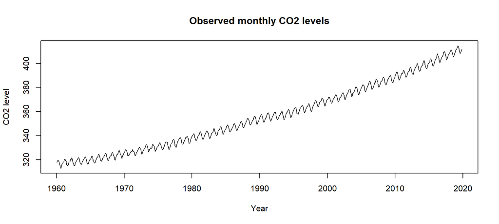

As expected we see an increase. There also seems to be a seasonal trend.

We can decompse the timeseries to get a closer look.

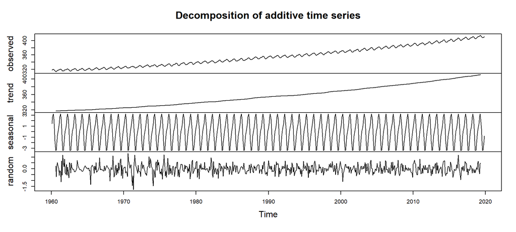

With this we see a much clearer sesonal trend.

The data is definitely not stationary, thus we apply differencing ($\nabla$) to see if it gets any better.

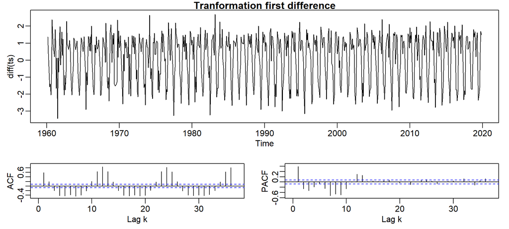

Applying $\nabla^2$:

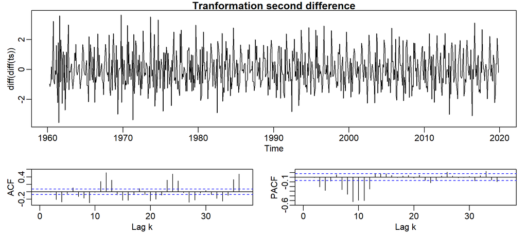

Does not seem to get any better.

We try capturing the seasonal trend. We expect that a season last for a year, so 12 months seems like a good starting point for differencing. Applying $\nabla^{12}$ we get:

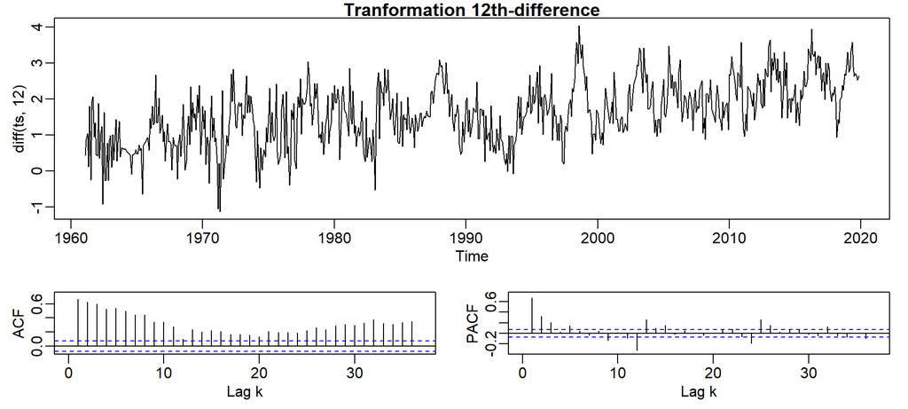

With this it seems we have removed the seasonal component. But it is clearly not completly stationary. We try applying $\nabla\nabla^{12}$ to capture the lag:

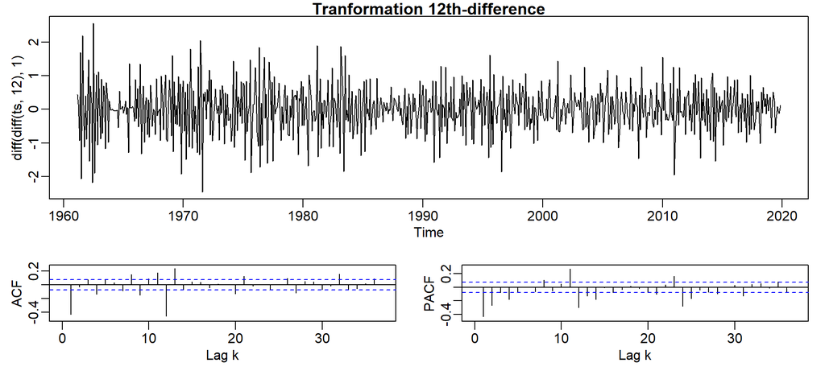

Which seems somewhat stationary, we could increase the lag to get a better fit, but as we prefer simple models, and we want to avoid overfitting, we decide to use $\nabla\nabla^{12}$ to tranform.

We will later see that the acf plot improve form.

There parameters results in a SARIMA model.

(Coefficient can i.e. be fit using innovations algoritihm. But that might not be the method impletemented in the package).

With this chose of parameters our model would be:
$$\phi(B)\Phi(B)X_t = \theta(B)\Theta(B)Z_ t$$
$$\theta(z)=1+\theta_1z$$
$$\Theta(z)=1+\Theta_1z$$
$$\phi(z)=1-\phi_1z+\dots+\phi_ 4z^4$$
$$\Phi(z)=1-\Phi_1z+\dots+\Phi_5z^5$$

Fitting the model with the selected parameters, we get the following diagnostic:

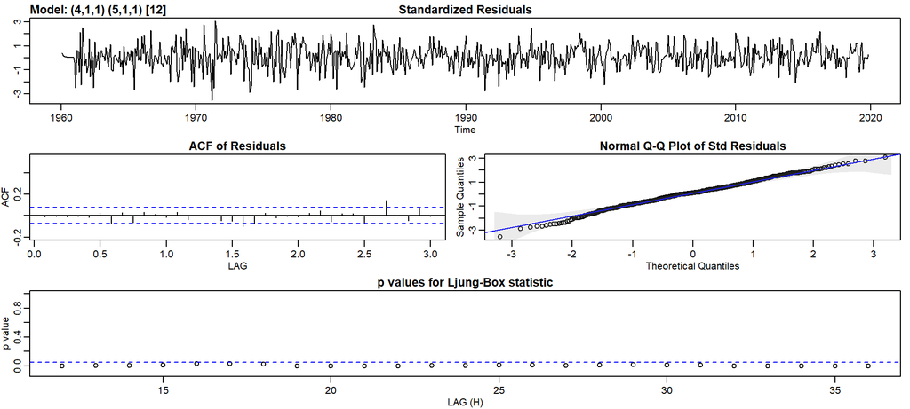

And the following coefficients:

```
##        phi1        phi2        phi3        phi4      theta1        Phi1
## -0.05851883 -0.06976959 -0.02473830 -0.11904962 -0.51345326 -0.01650475
##        Phi2        Phi3        Phi4        Phi5      Theta1
## -0.09926963  0.01414698 -0.11440507 -0.07581437 -0.82967466
```

The standardized residuals seems to be random, and there are not clear trend. The residuals seems homoscedastic and are centered at zero, which is a good indcation that our models assumptions are held by the data.

Looking at the autocorrolation plot, there does not seem to be any lag corrolating that much. Still, there are a few outliers, but that is often on 12+ months and can be considered to be well within the range of some family wise error rate.

Points in the qq-plot also seems to align with the normal line quite well, which indicate a good fit for our model.

## Confidence interval for coefficients

We use bootstrapping to create confidence intervals for the coeffiecients. Using bootstraping we create a simulated data-set by drawing at random from our original data set, and fit a model using this. We repeat this, and in the end get a set of possible coefficient values, which we can use to confidence intervals. We will use a a blocked bootstrap method. Blocked bootstraping is to select adjunct sections from the timeseries at random and join the selections together (Hyndman and Athanasopoulos 2018).

For the coefficients we get the following bootstrapped confidence intervals (95%) using 200 samples:

```
##                  phi1        phi2        phi3       phi4     theta1
## lower 2.5% -0.1822252 -0.28560066 -0.27060160 -0.2218933 -0.7799848
## upper 2.5%  0.4505167 -0.05617251 -0.03621915 -0.0521043 -0.2397842
##                  Phi1        Phi2        Phi3        Phi4        Phi5
## lower 2.5% -0.1527267 -0.17364720 -0.12560727 -0.11921476 -0.10586522
## upper 2.5%  0.0596933  0.05461404  0.07821557  0.05451245  0.04177681
##                Theta1
## lower 2.5% -0.9480253
## upper 2.5% -0.7909041
```

## Forecasting with bootstrapping

Bootstrapping can also be used to obtain prediction interval as the ones gained with traditional methods is often too narrow. We again use blocked bootstrapping.

The methods used in this section is adapted from Hyndman and Athanasopoulos’s bootstrapping and bagging chapter.

We the fit different models, on 200 bootstrap samples:

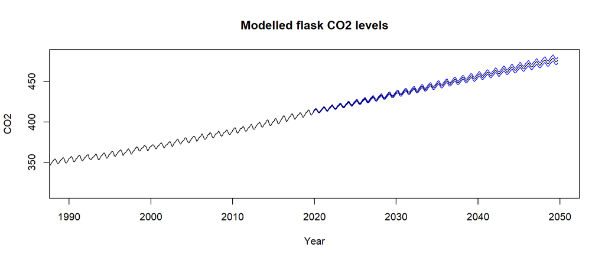

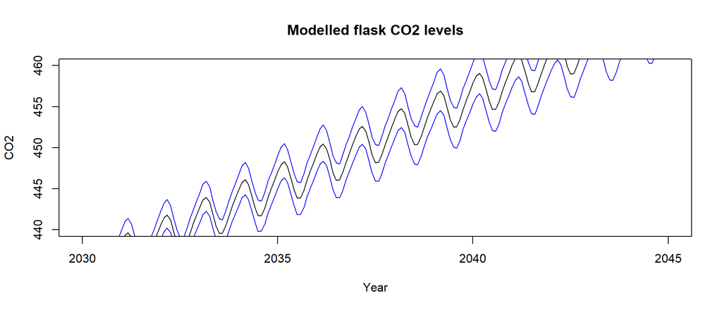

# Discussion and Conclusion

We chose differencing over detrending to remove trend elements in our data as our goal is to coerce the data to stationarity for the purposes of fitting a model (2017 Time Series analysis and Its applications P.56)

Since our data was non-stationary, an ARIMA model seemed appropriate. Our data displays a clear seasonal pattern. The earth’s ecosystem in general, and weather in particular, are seasonal, and it is reasonable to assume that co2 levels at a measuring station is correlated with changing weather. Therefore, a model that takes this into account is suitable, leading to our choice of a SARIMA model. Selecting the parameters for our model is done by testing all combinations of parameter values up to 5 and then picking the one with the smallest AICC score. It would seem intuitive to some to set very high values for our paramters to take into account large numbers of past states, but this would lead to an overly complex model and overfitting. It is therefore prudent to explore parameters including only a few previous states in the model.

We can conclude from our analysis and model that co2 levels will keep increasing into the future at a rate similar to the current rate.

# References

C. D. Keeling, S. C. Piper, R. B. Bacastow, M. Wahlen, T. P. Whorf, M. Heimann, and H. A. Meijer, *Exchanges of atmospheric CO2 and 13CO2 with the terrestrial biosphere and oceans from 1978 to 2000.* I. Global aspects, SIO Reference Series , No. 01-06, Scripps Institution of Oceanography, San Diego, 88 pages, 2001.

Brockwell, Peter J., and Richard A. Davis. 2016. *Introduction to Time Series and Forecasting*. Springer.

Hyndman, Rob J., and George Athanasopoulos. 2018. *Forecasting: Principles and Practice*. OTexts.

Shumway, Robert H., and David S. Stoffer. 2017. *Time Series Analysis and Its Applications: With R Examples*. Springer.